# R Workshop 6 - Tidyverse introduction with Pipes and dplyr

Andrew Moles

Learning Developer, Digital Skills Lab

23 July, 2021

# What this workshop will cover

- Introduce the use of pipes
- Indexing with the select function from dplyr
- Conditional indexing of data with the filter function from dplyr

## Why this style?

- Online training is tiring so keeping the sessions to one hour
- No or limited demonstrations provided in order to provide more real world experience - you have a problem and you look up how to solve it, adapting example code
- Trainer support to guide through process of learning

## We will be working in pairs:

- Option to work together on worksheet or to work individually
- If possible have your camera on and introduce yourself to each other

## What to do when getting stuck:

1. Ask your team members
2. Search online:
- The answer box on the top of Google’s results page
- stackoverflow.com (for task-specific solutions)
- https://www.r-bloggers.com/ (topic based tutorials)
3. Don’t struggle too long looking online, ask the trainer if you can’t find a solution!

# What is the tidyverse?

[figure not shown]

image credit: Analytics Vidhya

The tidyverse is a collection of R packages that are designed for data science. These packages share design, syntax, and philosophy. These packages cover the import of data (`readr` and `haven`), manipulation and transformation of data (`dplyr`, `tidyr`, `stringr`, `purrr`, `forcats`, and `lubridate`), visualisation (`ggplot` and it’s extensions), and analysis (`tidymodels`).

Essentially, the tidyverse makes data science in R less painless, improving your experience of R and data science, especially in the data cleaning and wrangling stages.

# What is tidy data?

The tidyverse has a focus on working with tidy data, or making data tidy, ready for visualisation and analysis. So what does tidy data mean?

When your data is tidy, *each column is a variable*, *each row is an observation*, and *each cell is a single observation*, as per our example below:

```r
# tidy data example
tidy_df <- data.frame(
  id = 1:6,
  name = c("floof", "max", "cat", "donut", "merlin", "panda"),
  colour = c("grey", "black", "orange", "grey", "black", "calico")
)

tidy_df
```

```
##   id   name colour
## 1  1  floof   grey
## 2  2    max  black
## 3  3    cat orange
## 4  4  donut   grey
## 5  5 merlin  black
## 6  6  panda calico
```

Messy data is inconsistent and unique, making it harder to work with, and harder for others to work with. See this example of a messy dataset that would be hard to work with. We would have to split up the animal column to name and colour. In later workshops, we will cover how to deal with messy data.

```r
# example messy data frame
messy_df <- data.frame(
  id = c(1,1,2,2,3,3,4,4,5,5,6,6),
  animal = c("floof", "grey",
             "max", "black",
             "cat", "orange",
             "donut", "grey",
             "merlin", "black",
             "panda", "calico")
)

messy_df
```

```
##    id animal
## 1   1  floof
## 2   1   grey
## 3   2    max
## 4   2  black
## 5   3    cat
## 6   3 orange
## 7   4  donut
## 8   4   grey
## 9   5 merlin
## 10  5  black
## 11  6  panda
## 12  6 calico
```

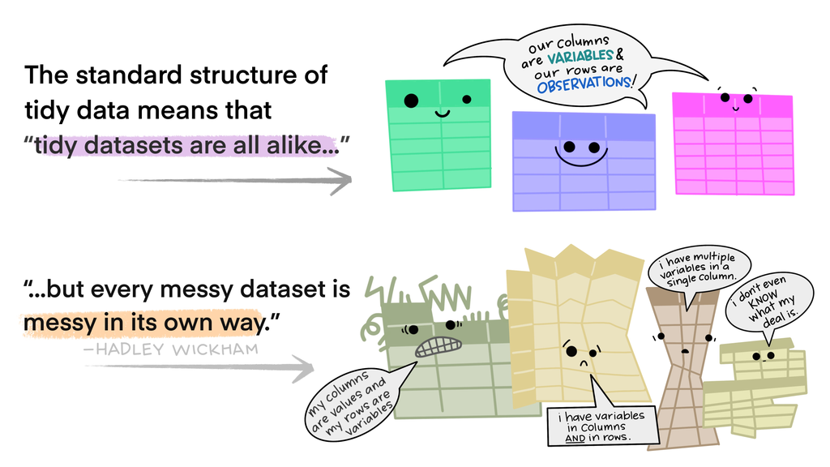

Image credit: Julie Lowndes and Allison Horst

See this excellent article, which has lots of nice images, for a summary :-https://www.openscapes.org/blog/2020/10/12/tidy-data/

# Package install task

In this workshop we will be using three packages: magrittr, dplyr, and readr.

Using the code chunk below, install all three of these packages. *note that dplyr is large and might take a minute or so to install*

```r
# your code here
install.packages("")
install.packages("")
install.packages("")
```

*Also note that you can install the whole tidyverse with install.packages(“tidyverse”)! This takes a while though, so for this workshop we will just install individual packages.*

# Intro to pipes

The pipe operator in R comes from the `magrittr` package, using syntax of `%>%`.

The pipe operator is for chaining a sequence of operations together. This has two main advantages: it makes your code more readable, and it saves some typing.

The syntax is `data %>% function`, as shown in the example below. The data gets *piped* into the function.

```r
library(magrittr)

data <- c(4.1 ,1.7, 1.1, 7.5, 1.7)

data %>% mean()
```

```
## [1] 3.22
```

To see the difference between using pipes and not using pipes, look at the following examples.

We are going to calculate a mean of a vector of numbers, round the result, and print it using paste.

```r
# Make some data: 20 randomly selected data points, from 1 to 10
x <- sample(1:10, 20, replace = TRUE)
y <- sample(1:10, 20, replace = TRUE)

# without pipe
y_mean <- mean(y)
y_mean <- round(y_mean, digits = 2)
y_mean <- paste("Mean value of y is", y_mean)
y_mean
```

```
## [1] "Mean value of y is 5.9"
```

```r
# without pipe in one line
paste("Mean value of y is", round(mean(y), digits = 2))
```

```
## [1] "Mean value of y is 5.9"
```

Now lets have a look at how to do this same set of operations with pipes. The process is as follows: assign x to x_mean, then pipe to x to a mean function, pipe the result of mean to round, finally assign result to paste.

You will notice in the paste function we have used a `.` after the text. This is called a *place-holder*, whereby instead of using the data (like we did above without the pipe) we add a `.` to tell R that is where we want our data to go.

```r
# load in magrittr
library(magrittr)

# magrittr pipe
x_mean <- x %>% # assign result at the start
  mean() %>%
  round(digits = 2) %>%
  paste("Mean value of x is", .) # we use the . as a place holder for a variable (e.g. instead of x)

x_mean
```

```
## [1] "Mean value of x is 4.7"
```

Notice how we assign the result at the start just like we would usually do, then pipe from then on.

It is also worth mentioning that as of version 4.1 of R, base R comes with a native pipe operator. This has just been introduced, and may get more use in examples you’ll see online in the future. The syntax uses `|>` as the pipe, and the structure is the same as a magrittr pipe.

*note that the native pipe currently doesn’t have a place-holder, so we won’t use paste in this example*

```r
# native R pipe
z <- sample(1:10, 20, replace = TRUE)

z_mean <- z |>
  mean() |>
  round(digits = 2)

z_mean
```

```
## [1] 4.85
```

If the above example doesn’t work, it means you have a version of R that is less than 4.1. Run the below code chunk to test out your R version. If it is less than 4.1 you can update it after the workshop.

```r
# test your r version
R.version.string
```

```
## [1] "R version 4.1.0 (2021-05-18)"
```

We will be using the magrittr pipe (`%>%`) for the rest of this workshop, as it’s currently the pipe operator you will come across most in the r world.

## Exercise - using pipes

Using the vector of temperature provided and using magrittr pipes:

1. Pipe median and paste functions together to get a final result that looks like: *“median temp is 15”*
2. Pipe max and paste functions together to get a final result that looks like: *“max temp is 20”*

*hint: don’t forget to use the place-holder with paste*

```r
library(magrittr)

temperature <- c(10, 16, 12, 15, 14, 15, 20)

# your code here
temperature %>%
  median() %>%
  paste("median temp is", .)
```

```
## [1] "median temp is 15"
```

```r
temperature %>%
  max() %>%
  paste("max temp is", .)
```

```
## [1] "max temp is 20"
```

# Introduction to dplyr

Dplyr is a package that is built for data manipulation, using functions that describe what they do. For example, the `select()` function selects columns you want, or don’t want, from a data frame.

The dplyr package has a lot of functions built into the package, each has it’s own very helpful documentation page with examples - https://dplyr.tidyverse.org/reference/index.html

Dplyr functions work with and without pipes and you’ll see both when searching online. If using a pipe, you call your data then pipe that to a function, such as `data %>% mean()`. If you are not using a pipe, you call your data within the function, such as `mean(data)`.

We will focus on two key dplyr functions for now: `select()` and `filter()`. We will use the messi_career data for the examples. Run the code chunk below to get the data into r and have a look at it.

```r
# create the messi career data
messi_career <- data.frame(Appearances = c(9,25,36,40,51,53,55,60,50,46,57,49,52,54,50,44),
                           Goals = c(1,8,17,16,38,47,53,73,60,41,58,41,54,45,51,31),
                           Season = c(2004,2005,2006,2007,2008,2009,2010,2011,2012,
            2013,2014,2015,2016,2017,2018,2019),
                           Club = rep("FC Barcelona", 16),
                          Age = seq(17, 32),
                          champLeagueGoal = c(0,1,1,6,9,8,12,14,8,8,10,6,11,6,12,3))
# view the data
head(messi_career)
```

```
##   Appearances Goals Season         Club Age champLeagueGoal
## 1           9     1   2004 FC Barcelona  17               0
## 2          25     8   2005 FC Barcelona  18               1
## 3          36    17   2006 FC Barcelona  19               1
## 4          40    16   2007 FC Barcelona  20               6
## 5          51    38   2008 FC Barcelona  21               9
## 6          53    47   2009 FC Barcelona  22               8
```

## Select function

The select function subsets columns from a data frame using their name. There are several different ways of using select. Run each of the code chunks below and review the outputs.

First, we can give the names of the columns we want to select.

```r
# load dplyr
library(dplyr)

# select single column
messi_career %>% select(Goals)
```

```
##    Goals
## 1      1
## 2      8
## 3     17
## 4     16
## 5     38
## 6     47
## 7     53
## 8     73
## 9     60
## 10    41
## 11    58
## 12    41
## 13    54
## 14    45
## 15    51
## 16    31
```

```r
# select all but single column
messi_career %>% select(-Goals)
```

```
##    Appearances Season         Club Age champLeagueGoal
## 1            9   2004 FC Barcelona  17               0
## 2           25   2005 FC Barcelona  18               1
## 3           36   2006 FC Barcelona  19               1
## 4           40   2007 FC Barcelona  20               6
## 5           51   2008 FC Barcelona  21               9
## 6           53   2009 FC Barcelona  22               8
## 7           55   2010 FC Barcelona  23              12
## 8           60   2011 FC Barcelona  24              14
## 9           50   2012 FC Barcelona  25               8
## 10          46   2013 FC Barcelona  26               8
## 11          57   2014 FC Barcelona  27              10
## 12          49   2015 FC Barcelona  28               6
## 13          52   2016 FC Barcelona  29              11
## 14          54   2017 FC Barcelona  30               6
## 15          50   2018 FC Barcelona  31              12
## 16          44   2019 FC Barcelona  32               3
```

```r
# select multiple columns
messi_career %>% select(Appearances, Goals, Age)
```

```
##    Appearances Goals Age
## 1            9     1  17
## 2           25     8  18
## 3           36    17  19
## 4           40    16  20
## 5           51    38  21
## 6           53    47  22
## 7           55    53  23
## 8           60    73  24
## 9           50    60  25
## 10          46    41  26
## 11          57    58  27
## 12          49    41  28
## 13          52    54  29
## 14          54    45  30
## 15          50    51  31
## 16          44    31  32
```

Another method is using a range of columns, known as a slice. Here we are selecting columns from Season to Age, which includes the Club column as well. We can also combine this with the ! (not) operator to exclude those columns.

```r
# select slice (or range) of columns
messi_career %>% select(Season:Age)
```

```
##    Season         Club Age
## 1    2004 FC Barcelona  17
## 2    2005 FC Barcelona  18
## 3    2006 FC Barcelona  19
## 4    2007 FC Barcelona  20
## 5    2008 FC Barcelona  21
## 6    2009 FC Barcelona  22
## 7    2010 FC Barcelona  23
## 8    2011 FC Barcelona  24
## 9    2012 FC Barcelona  25
## 10   2013 FC Barcelona  26
## 11   2014 FC Barcelona  27
## 12   2015 FC Barcelona  28
## 13   2016 FC Barcelona  29
## 14   2017 FC Barcelona  30
## 15   2018 FC Barcelona  31
## 16   2019 FC Barcelona  32
```

```r
# select slice and other columns
messi_career %>% select(Appearances:Season, champLeagueGoal)
```

```
##    Appearances Goals Season champLeagueGoal
## 1            9     1   2004               0
## 2           25     8   2005               1
## 3           36    17   2006               1
## 4           40    16   2007               6
## 5           51    38   2008               9
## 6           53    47   2009               8
## 7           55    53   2010              12
## 8           60    73   2011              14
## 9           50    60   2012               8
## 10          46    41   2013               8
## 11          57    58   2014              10
## 12          49    41   2015               6
## 13          52    54   2016              11
## 14          54    45   2017               6
## 15          50    51   2018              12
## 16          44    31   2019               3
```

```r
# negate selection of columns
messi_career %>% select(!(Season:Age))
```

```
##    Appearances Goals champLeagueGoal
## 1            9     1               0
## 2           25     8               1
## 3           36    17               1
## 4           40    16               6
## 5           51    38               9
## 6           53    47               8
## 7           55    53              12
## 8           60    73              14
## 9           50    60               8
## 10          46    41               8
## 11          57    58              10
## 12          49    41               6
## 13          52    54              11
## 14          54    45               6
## 15          50    51              12
## 16          44    31               3
```

```r
# negate selection with slice and extra column (note c() function used)
messi_career %>% select(!c(Season:Age, champLeagueGoal))
```

```
##    Appearances Goals
## 1            9     1
## 2           25     8
## 3           36    17
## 4           40    16
## 5           51    38
## 6           53    47
## 7           55    53
## 8           60    73
## 9           50    60
## 10          46    41
## 11          57    58
## 12          49    41
## 13          52    54
## 14          54    45
## 15          50    51
## 16          44    31
```

As you can see, `select()` makes it easy to extract columns from your data, and becomes more useful the larger your dataset becomes.

In the examples above we did not assign the result. See the examples below on how to do this.

```r
# assign result to subset
messi_sub <- messi_career %>%
  select(Appearances, Goals, Age)

messi_sub
```

```
##    Appearances Goals Age
## 1            9     1  17
## 2           25     8  18
## 3           36    17  19
## 4           40    16  20
## 5           51    38  21
## 6           53    47  22
## 7           55    53  23
## 8           60    73  24
## 9           50    60  25
## 10          46    41  26
## 11          57    58  27
## 12          49    41  28
## 13          52    54  29
## 14          54    45  30
## 15          50    51  31
## 16          44    31  32
```

```r
# The no pipe method
messi_sub <- select(messi_career, Appearances, Goals, Age)
```

## Select exercise

For your exercises, you will be using imdb movie data! I’ve loaded it here in the code for you.

1. Run the code currenty in the code chunk to load the libraries and the data, and review the output from `glimpse()`
2. Using select with pipes, subset the `imdb_movie` data so you have the following columns: imdb_id through to writer, actors, avg_vote to votes, reviews_from_users to reviews_from_critics. Assign the result to `imdb_sub`
3. Use glimpse to review the subsetted data: *data %>% glimpse()*
4. There is a more efficient way of doing this using select. From looking at the examples provided, can you think of a better way of taking out the columns we removed?

*hint: you should be able to fit this into one select call*

```r
# load libraries
library(readr)
library(dplyr)

# load data
movies_imdb <- read_csv("https://raw.githubusercontent.com/andrewmoles2/rTrainIntroduction/master/Workshop6/data/IMDb%20movies.csv")

# use glimpse to review data (tidyverse version of str())
movies_imdb %>% glimpse()
```

```
## Rows: 85,855
## Columns: 21
## $ imdb_title_id         <chr> "tt0000009", "tt0000574", "tt0001892", "tt000210…
## $ title                 <chr> "Miss Jerry", "The Story of the Kelly Gang", "De…
## $ year                  <dbl> 1894, 1906, 1911, 1912, 1911, 1912, 1919, 1913, …
## $ date_published        <chr> "1894-10-09", "26/12/1906", "19/08/1911", "13/11…
## $ genre                 <chr> "Romance", "Biography, Crime, Drama", "Drama", "…
## $ duration              <dbl> 45, 70, 53, 100, 68, 60, 85, 120, 120, 55, 121, …
## $ country               <chr> "USA", "Australia", "Germany, Denmark", "USA", "…
## $ language              <chr> "None", "None", NA, "English", "Italian", "Engli…
## $ director              <chr> "Alexander Black", "Charles Tait", "Urban Gad", …
## $ writer                <chr> "Alexander Black", "Charles Tait", "Urban Gad, G…
## $ production_company    <chr> "Alexander Black Photoplays", "J. and N. Tait", …
## $ actors                <chr> "Blanche Bayliss, William Courtenay, Chauncey De…
## $ description           <chr> "The adventures of a female reporter in the 1890…
## $ avg_vote              <dbl> 5.9, 6.1, 5.8, 5.2, 7.0, 5.7, 6.8, 6.2, 6.7, 5.5…
## $ votes                 <dbl> 154, 589, 188, 446, 2237, 484, 753, 273, 198, 22…
## $ budget                <chr> NA, "$ 2250", NA, "$ 45000", NA, NA, NA, "ITL 45…
## $ usa_gross_income      <chr> NA, NA, NA, NA, NA, NA, NA, NA, NA, NA, NA, NA, …
## $ worlwide_gross_income <chr> NA, NA, NA, NA, NA, NA, NA, NA, NA, NA, NA, NA, …
## $ metascore             <dbl> NA, NA, NA, NA, NA, NA, NA, NA, NA, NA, NA, NA, …
## $ reviews_from_users    <dbl> 1, 7, 5, 25, 31, 13, 12, 7, 4, 8, 9, 9, 16, 8, N…
## $ reviews_from_critics  <dbl> 2, 7, 2, 3, 14, 5, 9, 5, 1, 1, 9, 28, 7, 23, 4, …
```

```r
# your code here
imdb_sub <- movies_imdb %>%
  select(imdb_title_id:writer, actors, avg_vote:votes, reviews_from_users:reviews_from_critics)

imdb_sub %>% glimpse()
```

```
## Rows: 85,855
## Columns: 15
## $ imdb_title_id        <chr> "tt0000009", "tt0000574", "tt0001892", "tt0002101…
## $ title                <chr> "Miss Jerry", "The Story of the Kelly Gang", "Den…
## $ year                 <dbl> 1894, 1906, 1911, 1912, 1911, 1912, 1919, 1913, 1…
## $ date_published       <chr> "1894-10-09", "26/12/1906", "19/08/1911", "13/11/…
## $ genre                <chr> "Romance", "Biography, Crime, Drama", "Drama", "D…
## $ duration             <dbl> 45, 70, 53, 100, 68, 60, 85, 120, 120, 55, 121, 5…
## $ country              <chr> "USA", "Australia", "Germany, Denmark", "USA", "I…
## $ language             <chr> "None", "None", NA, "English", "Italian", "Englis…
## $ director             <chr> "Alexander Black", "Charles Tait", "Urban Gad", "…
## $ writer               <chr> "Alexander Black", "Charles Tait", "Urban Gad, Ge…
## $ actors               <chr> "Blanche Bayliss, William Courtenay, Chauncey Dep…
## $ avg_vote             <dbl> 5.9, 6.1, 5.8, 5.2, 7.0, 5.7, 6.8, 6.2, 6.7, 5.5,…
## $ votes                <dbl> 154, 589, 188, 446, 2237, 484, 753, 273, 198, 225…
## $ reviews_from_users   <dbl> 1, 7, 5, 25, 31, 13, 12, 7, 4, 8, 9, 9, 16, 8, NA…
## $ reviews_from_critics <dbl> 2, 7, 2, 3, 14, 5, 9, 5, 1, 1, 9, 28, 7, 23, 4, 2…
```

# Select helper functions

So far we have selected just columns we named, but there are other methods we can use. Dplyr has a number of *helper* functions that come with `select()`.

One such example is the `contains()` function, that finds columns that contain the string a string. This is a useful option if you just want to pick out columns that have some similar text in them.

```r
# select by literal string
messi_career %>% select(contains("Goal"))
```

```
##    Goals champLeagueGoal
## 1      1               0
## 2      8               1
## 3     17               1
## 4     16               6
## 5     38               9
## 6     47               8
## 7     53              12
## 8     73              14
## 9     60               8
## 10    41               8
## 11    58              10
## 12    41               6
## 13    54              11
## 14    45               6
## 15    51              12
## 16    31               3
```

Other options are the `starts_with()` or `ends_with()` helpers. You provide a string of what your column either starts with or ends with, and they will be selected.

```r
# columns starting with A
messi_career %>%
  select(starts_with("A"))
```

```
##    Appearances Age
## 1            9  17
## 2           25  18
## 3           36  19
## 4           40  20
## 5           51  21
## 6           53  22
## 7           55  23
## 8           60  24
## 9           50  25
## 10          46  26
## 11          57  27
## 12          49  28
## 13          52  29
## 14          54  30
## 15          50  31
## 16          44  32
```

```r
# columns ending with s
messi_career %>%
  select(ends_with("s"))
```

```
##    Appearances Goals
## 1            9     1
## 2           25     8
## 3           36    17
## 4           40    16
## 5           51    38
## 6           53    47
## 7           55    53
## 8           60    73
## 9           50    60
## 10          46    41
## 11          57    58
## 12          49    41
## 13          52    54
## 14          54    45
## 15          50    51
## 16          44    31
```

```r
# columns not starting with A
messi_career %>%
  select(!starts_with("A"))
```

```
##    Goals Season         Club champLeagueGoal
## 1      1   2004 FC Barcelona               0
## 2      8   2005 FC Barcelona               1
## 3     17   2006 FC Barcelona               1
## 4     16   2007 FC Barcelona               6
## 5     38   2008 FC Barcelona               9
## 6     47   2009 FC Barcelona               8
## 7     53   2010 FC Barcelona              12
## 8     73   2011 FC Barcelona              14
## 9     60   2012 FC Barcelona               8
## 10    41   2013 FC Barcelona               8
## 11    58   2014 FC Barcelona              10
## 12    41   2015 FC Barcelona               6
## 13    54   2016 FC Barcelona              11
## 14    45   2017 FC Barcelona               6
## 15    51   2018 FC Barcelona              12
## 16    31   2019 FC Barcelona               3
```

## Select helper exercise

Using the imdb_sub dataset you made in the previous exercise:

```r
# your code here

# cols containing vote
imdb_sub %>%
  select(contains("vote"))
```

```
## # A tibble: 85,855 x 2
##    avg_vote votes
##       <dbl> <dbl>
##  1      5.9   154
##  2      6.1   589
##  3      5.8   188
##  4      5.2   446
##  5      7    2237
##  6      5.7   484
##  7      6.8   753
##  8      6.2   273
##  9      6.7   198
## 10      5.5   225
## # … with 85,845 more rows
```

```r
# cols starting with d
imdb_sub %>%
  select(starts_with("d"))
```

```
## # A tibble: 85,855 x 3
##    date_published duration director
##    <chr>             <dbl> <chr>
##  1 1894-10-09           45 Alexander Black
##  2 26/12/1906           70 Charles Tait
##  3 19/08/1911           53 Urban Gad
##  4 13/11/1912          100 Charles L. Gaskill
##  5 06/03/1911           68 Francesco Bertolini, Adolfo Padovan
##  6 1913                 60 Sidney Olcott
##  7 26/11/1919           85 Ernst Lubitsch
##  8 01/03/1913          120 Enrico Guazzoni
##  9 01/09/1912          120 Aristide Demetriade, Grigore Brezeanu
## 10 15/10/1912           55 André Calmettes, James Keane
## # … with 85,845 more rows
```

```r
# cols ending with e
imdb_sub %>%
  select(ends_with("e"))
```

```
## # A tibble: 85,855 x 4
##    title                                   genre               language avg_vote
##    <chr>                                   <chr>               <chr>       <dbl>
##  1 Miss Jerry                              Romance             None          5.9
##  2 The Story of the Kelly Gang             Biography, Crime, … None          6.1
##  3 Den sorte drøm                          Drama               <NA>          5.8
##  4 Cleopatra                               Drama, History      English       5.2
##  5 L'Inferno                               Adventure, Drama, … Italian       7
##  6 From the Manger to the Cross; or, Jesu… Biography, Drama    English       5.7
##  7 Madame DuBarry                          Biography, Drama, … German        6.8
##  8 Quo Vadis?                              Drama, History      Italian       6.2
##  9 Independenta Romaniei                   History, War        <NA>          6.7
## 10 Richard III                             Drama               English       5.5
## # … with 85,845 more rows
```

```r
# cols starting with d or ending with r
imdb_sub %>%
  select(starts_with("d") | ends_with("r"))
```

```
## # A tibble: 85,855 x 5
##    date_published duration director                  year writer
##    <chr>             <dbl> <chr>                    <dbl> <chr>
##  1 1894-10-09           45 Alexander Black           1894 Alexander Black
##  2 26/12/1906           70 Charles Tait              1906 Charles Tait
##  3 19/08/1911           53 Urban Gad                 1911 Urban Gad, Gebhard Sc…
##  4 13/11/1912          100 Charles L. Gaskill        1912 Victorien Sardou
##  5 06/03/1911           68 Francesco Bertolini, Ad…  1911 Dante Alighieri
##  6 1913                 60 Sidney Olcott             1912 Gene Gauntier
##  7 26/11/1919           85 Ernst Lubitsch            1919 Norbert Falk, Hanns K…
##  8 01/03/1913          120 Enrico Guazzoni           1913 Henryk Sienkiewicz, E…
##  9 01/09/1912          120 Aristide Demetriade, Gr…  1912 Aristide Demetriade, …
## 10 15/10/1912           55 André Calmettes, James …  1912 James Keane, William …
## # … with 85,845 more rows
```

# Using select to change column order

It is also helpful to change the order of your columns, and you can use `select` to do this.

If we wanted to move the club column as the first column in our messi_career data, we could do it manually but naming all the columns like the example below.

```r
# manually
messi_career %>%
  select(Club, Appearances, Goals, Season, Age, champLeagueGoal)
```

```
##            Club Appearances Goals Season Age champLeagueGoal
## 1  FC Barcelona           9     1   2004  17               0
## 2  FC Barcelona          25     8   2005  18               1
## 3  FC Barcelona          36    17   2006  19               1
## 4  FC Barcelona          40    16   2007  20               6
## 5  FC Barcelona          51    38   2008  21               9
## 6  FC Barcelona          53    47   2009  22               8
## 7  FC Barcelona          55    53   2010  23              12
## 8  FC Barcelona          60    73   2011  24              14
## 9  FC Barcelona          50    60   2012  25               8
## 10 FC Barcelona          46    41   2013  26               8
## 11 FC Barcelona          57    58   2014  27              10
## 12 FC Barcelona          49    41   2015  28               6
## 13 FC Barcelona          52    54   2016  29              11
## 14 FC Barcelona          54    45   2017  30               6
## 15 FC Barcelona          50    51   2018  31              12
## 16 FC Barcelona          44    31   2019  32               3
```

This could get really messy if you have lots of data. Two helper functions make this much easier: `everything()` and `last_col()`. Everything selects every column not already specified, so is useful if we want to move a column to the first column in the dataset.

```r
# move club to first column
messi_career %>%
  select(Club, everything())
```

```
##            Club Appearances Goals Season Age champLeagueGoal
## 1  FC Barcelona           9     1   2004  17               0
## 2  FC Barcelona          25     8   2005  18               1
## 3  FC Barcelona          36    17   2006  19               1
## 4  FC Barcelona          40    16   2007  20               6
## 5  FC Barcelona          51    38   2008  21               9
## 6  FC Barcelona          53    47   2009  22               8
## 7  FC Barcelona          55    53   2010  23              12
## 8  FC Barcelona          60    73   2011  24              14
## 9  FC Barcelona          50    60   2012  25               8
## 10 FC Barcelona          46    41   2013  26               8
## 11 FC Barcelona          57    58   2014  27              10
## 12 FC Barcelona          49    41   2015  28               6
## 13 FC Barcelona          52    54   2016  29              11
## 14 FC Barcelona          54    45   2017  30               6
## 15 FC Barcelona          50    51   2018  31              12
## 16 FC Barcelona          44    31   2019  32               3
```

Last col calls the last column in your data frame, so we can call `last_col()` to move ‘champLeagueGoal’ to the first column, then use everything to keep the rest of the columns as they are.

```r
# move last column to first column
messi_career %>%
  select(last_col(), everything())
```

```
##    champLeagueGoal Appearances Goals Season         Club Age
## 1                0           9     1   2004 FC Barcelona  17
## 2                1          25     8   2005 FC Barcelona  18
## 3                1          36    17   2006 FC Barcelona  19
## 4                6          40    16   2007 FC Barcelona  20
## 5                9          51    38   2008 FC Barcelona  21
## 6                8          53    47   2009 FC Barcelona  22
## 7               12          55    53   2010 FC Barcelona  23
## 8               14          60    73   2011 FC Barcelona  24
## 9                8          50    60   2012 FC Barcelona  25
## 10               8          46    41   2013 FC Barcelona  26
## 11              10          57    58   2014 FC Barcelona  27
## 12               6          49    41   2015 FC Barcelona  28
## 13              11          52    54   2016 FC Barcelona  29
## 14               6          54    45   2017 FC Barcelona  30
## 15              12          50    51   2018 FC Barcelona  31
## 16               3          44    31   2019 FC Barcelona  32
```

Another option is to use the `relocate()` function. This has the same syntax as select, but has extra functionally for moving columns with the `.after` and `.before` arguments.

By default, relocate will move the column you specify to the first column.

```r
# default moves to first column
messi_career %>%
  relocate(Club)
```

```
##            Club Appearances Goals Season Age champLeagueGoal
## 1  FC Barcelona           9     1   2004  17               0
## 2  FC Barcelona          25     8   2005  18               1
## 3  FC Barcelona          36    17   2006  19               1
## 4  FC Barcelona          40    16   2007  20               6
## 5  FC Barcelona          51    38   2008  21               9
## 6  FC Barcelona          53    47   2009  22               8
## 7  FC Barcelona          55    53   2010  23              12
## 8  FC Barcelona          60    73   2011  24              14
## 9  FC Barcelona          50    60   2012  25               8
## 10 FC Barcelona          46    41   2013  26               8
## 11 FC Barcelona          57    58   2014  27              10
## 12 FC Barcelona          49    41   2015  28               6
## 13 FC Barcelona          52    54   2016  29              11
## 14 FC Barcelona          54    45   2017  30               6
## 15 FC Barcelona          50    51   2018  31              12
## 16 FC Barcelona          44    31   2019  32               3
```

We call `.after` and `.before` like the examples below. We can also move more than one column.

```r
# move club to col after champLeagueGoal
messi_career %>%
  relocate(Club, .after = champLeagueGoal)
```

```
##    Appearances Goals Season Age champLeagueGoal         Club
## 1            9     1   2004  17               0 FC Barcelona
## 2           25     8   2005  18               1 FC Barcelona
## 3           36    17   2006  19               1 FC Barcelona
## 4           40    16   2007  20               6 FC Barcelona
## 5           51    38   2008  21               9 FC Barcelona
## 6           53    47   2009  22               8 FC Barcelona
## 7           55    53   2010  23              12 FC Barcelona
## 8           60    73   2011  24              14 FC Barcelona
## 9           50    60   2012  25               8 FC Barcelona
## 10          46    41   2013  26               8 FC Barcelona
## 11          57    58   2014  27              10 FC Barcelona
## 12          49    41   2015  28               6 FC Barcelona
## 13          52    54   2016  29              11 FC Barcelona
## 14          54    45   2017  30               6 FC Barcelona
## 15          50    51   2018  31              12 FC Barcelona
## 16          44    31   2019  32               3 FC Barcelona
```

```r
# move club to col before champLeagueGoal
messi_career %>%
  relocate(Club, Goals, .before = champLeagueGoal)
```

```
##    Appearances Season Age         Club Goals champLeagueGoal
## 1            9   2004  17 FC Barcelona     1               0
## 2           25   2005  18 FC Barcelona     8               1
## 3           36   2006  19 FC Barcelona    17               1
## 4           40   2007  20 FC Barcelona    16               6
## 5           51   2008  21 FC Barcelona    38               9
## 6           53   2009  22 FC Barcelona    47               8
## 7           55   2010  23 FC Barcelona    53              12
## 8           60   2011  24 FC Barcelona    73              14
## 9           50   2012  25 FC Barcelona    60               8
## 10          46   2013  26 FC Barcelona    41               8
## 11          57   2014  27 FC Barcelona    58              10
## 12          49   2015  28 FC Barcelona    41               6
## 13          52   2016  29 FC Barcelona    54              11
## 14          54   2017  30 FC Barcelona    45               6
## 15          50   2018  31 FC Barcelona    51              12
## 16          44   2019  32 FC Barcelona    31               3
```

## Column ordering exercise

Using the examples above:

1. Move the `year` column to be the first column in the `imdb_sub` data frame
2. Move the `avg_vote` column to be after the `year` column

```r
# your code here

# year as first column
imdb_sub %>%
  select(year, everything())
```

```
## # A tibble: 85,855 x 15
##     year imdb_title_id title     date_published genre  duration country language
##    <dbl> <chr>         <chr>     <chr>          <chr>     <dbl> <chr>   <chr>
##  1  1894 tt0000009     Miss Jer… 1894-10-09     Roman…       45 USA     None
##  2  1906 tt0000574     The Stor… 26/12/1906     Biogr…       70 Austra… None
##  3  1911 tt0001892     Den sort… 19/08/1911     Drama        53 German… <NA>
##  4  1912 tt0002101     Cleopatra 13/11/1912     Drama…      100 USA     English
##  5  1911 tt0002130     L'Inferno 06/03/1911     Adven…       68 Italy   Italian
##  6  1912 tt0002199     From the… 1913           Biogr…       60 USA     English
##  7  1919 tt0002423     Madame D… 26/11/1919     Biogr…       85 Germany German
##  8  1913 tt0002445     Quo Vadi… 01/03/1913     Drama…      120 Italy   Italian
##  9  1912 tt0002452     Independ… 01/09/1912     Histo…      120 Romania <NA>
## 10  1912 tt0002461     Richard … 15/10/1912     Drama        55 France… English
## # … with 85,845 more rows, and 7 more variables: director <chr>, writer <chr>,
## #   actors <chr>, avg_vote <dbl>, votes <dbl>, reviews_from_users <dbl>,
## #   reviews_from_critics <dbl>
```

```r
# avg_vote after year
imdb_sub %>%
  relocate(avg_vote, .after = year)
```

```
## # A tibble: 85,855 x 15
##    imdb_title_id title      year avg_vote date_published genre  duration country
##    <chr>         <chr>     <dbl>    <dbl> <chr>          <chr>     <dbl> <chr>
##  1 tt0000009     Miss Jer…  1894      5.9 1894-10-09     Roman…       45 USA
##  2 tt0000574     The Stor…  1906      6.1 26/12/1906     Biogr…       70 Austra…
##  3 tt0001892     Den sort…  1911      5.8 19/08/1911     Drama        53 German…
##  4 tt0002101     Cleopatra  1912      5.2 13/11/1912     Drama…      100 USA
##  5 tt0002130     L'Inferno  1911      7   06/03/1911     Adven…       68 Italy
##  6 tt0002199     From the…  1912      5.7 1913           Biogr…       60 USA
##  7 tt0002423     Madame D…  1919      6.8 26/11/1919     Biogr…       85 Germany
##  8 tt0002445     Quo Vadi…  1913      6.2 01/03/1913     Drama…      120 Italy
##  9 tt0002452     Independ…  1912      6.7 01/09/1912     Histo…      120 Romania
## 10 tt0002461     Richard …  1912      5.5 15/10/1912     Drama        55 France…
## # … with 85,845 more rows, and 7 more variables: language <chr>,
## #   director <chr>, writer <chr>, actors <chr>, votes <dbl>,
## #   reviews_from_users <dbl>, reviews_from_critics <dbl>
```

# Filter function

The filter function allows you to subset rows based on conditions, using conditional operators (==, <=, != etc.). It is similar to the base r `subset()` function which we have used in previous R workshops. The table below is a reminder of the conditional operators you can use.

[output not shown]

Just like when using `select`, you provide the column name you want to apply conditional logic to. If you are piping, you don’t need to provide your data as an argument in the function.

Run the examples below and review the outputs.

```r
# filter based on one criteria
messi_career %>% filter(Goals > 50)
```

```
##   Appearances Goals Season         Club Age champLeagueGoal
## 1          55    53   2010 FC Barcelona  23              12
## 2          60    73   2011 FC Barcelona  24              14
## 3          50    60   2012 FC Barcelona  25               8
## 4          57    58   2014 FC Barcelona  27              10
## 5          52    54   2016 FC Barcelona  29              11
## 6          50    51   2018 FC Barcelona  31              12
```

```r
# filter then pipe to select
messi_career %>% filter(Appearances >= 55) %>%
  select(Season, Age)
```

```
##   Season Age
## 1   2010  23
## 2   2011  24
## 3   2014  27
```

```r
# filter on more than one condition
messi_career %>% filter(Goals > 50 & champLeagueGoal <= 10)
```

```
##   Appearances Goals Season         Club Age champLeagueGoal
## 1          50    60   2012 FC Barcelona  25               8
## 2          57    58   2014 FC Barcelona  27              10
```

```r
# filter on average
messi_career %>% filter(Goals > mean(Goals, na.rm = TRUE))
```

```
##    Appearances Goals Season         Club Age champLeagueGoal
## 1           53    47   2009 FC Barcelona  22               8
## 2           55    53   2010 FC Barcelona  23              12
## 3           60    73   2011 FC Barcelona  24              14
## 4           50    60   2012 FC Barcelona  25               8
## 5           46    41   2013 FC Barcelona  26               8
## 6           57    58   2014 FC Barcelona  27              10
## 7           49    41   2015 FC Barcelona  28               6
## 8           52    54   2016 FC Barcelona  29              11
## 9           54    45   2017 FC Barcelona  30               6
## 10          50    51   2018 FC Barcelona  31              12
```

```r
# assign result to messi_sub
messi_sub <- messi_career %>%
  filter(Appearances <= 40) %>%
  select(Goals, Age)

# view result
messi_sub
```

```
##   Goals Age
## 1     1  17
## 2     8  18
## 3    17  19
## 4    16  20
```

## Filter exercise

We are going to filter our subsetted (`imdb_sub`) data to find the best rated films from the USA in the year 1989, and create a subset called USA_1989_high.

1. Pipe from imdb_sub to filter, filtering for country being equal to USA
2. Pipe from your country filter to another filter, filtering for year being equal to 1989
3. Pipe from your year filter to another filter. Filter for avg_vote to be greater than or equal to 7.5 and reviews_from_critics to be greater than 10
4. Make sure to assign your result to USA_1989_high
5. Print the result to see the highest rated films, made in the USA, in 1989.
6. Do you think you can put this into one filter command using the & operator?

```r
# your code here
# several filters
USA_1989_high <- imdb_sub %>%
  filter(country == "USA") %>%
  filter(year == 1989) %>%
  filter(avg_vote >= 7.5 & reviews_from_critics > 10)

# single filter
USA_1989_high <- imdb_sub %>%
  filter(country == "USA" &
           year == 1989 &
           avg_vote >= 7.5 &
           reviews_from_critics > 10)

# print result
USA_1989_high
```

```
## # A tibble: 12 x 15
##    imdb_title_id title     year date_published genre  duration country language
##    <chr>         <chr>    <dbl> <chr>          <chr>     <dbl> <chr>   <chr>
##  1 tt0096754     The Aby…  1989 22/12/1989     Adven…      171 USA     English
##  2 tt0096874     Back to…  1989 22/12/1989     Adven…      108 USA     English
##  3 tt0097123     Crimes …  1989 20/02/1990     Comed…      104 USA     English,…
##  4 tt0097165     Dead Po…  1989 29/09/1989     Comed…      128 USA     English,…
##  5 tt0097216     Do the …  1989 17/11/1989     Comed…      120 USA     English,…
##  6 tt0097351     Field o…  1989 05/05/1989     Drama…      107 USA     English
##  7 tt0097441     Glory     1989 16/02/1990     Biogr…      122 USA     English
##  8 tt0097576     Indiana…  1989 06/10/1989     Actio…      127 USA     English,…
##  9 tt0097757     The Lit…  1989 06/12/1990     Anima…       83 USA     English,…
## 10 tt0097958     Nationa…  1989 01/12/1989     Comedy       97 USA     English
## 11 tt0098635     When Ha…  1989 05/01/1990     Comed…       95 USA     English
## 12 tt0100049     Longtim…  1989 01/05/1990     Drama…       96 USA     English
## # … with 7 more variables: director <chr>, writer <chr>, actors <chr>,
## #   avg_vote <dbl>, votes <dbl>, reviews_from_users <dbl>,
## #   reviews_from_critics <dbl>
```

You might have noticed that the country column has some strings that are split by a comma, e.g. “Germany, Denmark”. The == operator will not be able to pick these up. Instead we would use the base R `grepl()` function or `str_detect()` from the `stringr` package. This won’t be covered in this workshop, but will be in future workshops. If you are interested, have a look at the stringr package - https://stringr.tidyverse.org/index.html.

# Other filtering options with dplyr

Other than conditional subsetting of data using `filter()`, dplyr has other functions we can use to subset our data: `slice`, `sample`, and `distinct.`

The sample functions randomly extract a set number of rows from your data. This is helpful if you want to take a random sample of your dataset. The examples below show the `sample_n()` and `sample_frac()` functions.

```r
# sample 5 rows
messi_career %>%
  sample_n(5)
```

```
##   Appearances Goals Season         Club Age champLeagueGoal
## 1          40    16   2007 FC Barcelona  20               6
## 2          36    17   2006 FC Barcelona  19               1
## 3          54    45   2017 FC Barcelona  30               6
## 4          57    58   2014 FC Barcelona  27              10
## 5          49    41   2015 FC Barcelona  28               6
```

```r
# sample 25% of your data
messi_career %>%
  sample_frac(0.25)
```

```
##   Appearances Goals Season         Club Age champLeagueGoal
## 1          46    41   2013 FC Barcelona  26               8
## 2          25     8   2005 FC Barcelona  18               1
## 3          44    31   2019 FC Barcelona  32               3
## 4          60    73   2011 FC Barcelona  24              14
```

The slice functions are more useful. The basic `slice` function is the equivalent of using numbered indexing in base r `data[1:5, ]`, but is designed to work better in the tidyverse enviroment.

```r
# select rows 4, 5, and 6
messi_career %>%
  slice(4:6)
```

```
##   Appearances Goals Season         Club Age champLeagueGoal
## 1          40    16   2007 FC Barcelona  20               6
## 2          51    38   2008 FC Barcelona  21               9
## 3          53    47   2009 FC Barcelona  22               8
```

```r
# equivalent in base r
messi_career[4:6, ]
```

```
##   Appearances Goals Season         Club Age champLeagueGoal
## 4          40    16   2007 FC Barcelona  20               6
## 5          51    38   2008 FC Barcelona  21               9
## 6          53    47   2009 FC Barcelona  22               8
```

The `slice_max` and `slice_min` functions are much more powerful, and are harder and messier to achieve with normal base r code. They allow you to index the rows that have the max (or min) in a specified column. In the example, we extract the rows that have the top three and bottom three values in the Goals column.

```r
# extract rows with top three Goals
messi_career %>%
  slice_max(Goals, n = 3)
```

```
##   Appearances Goals Season         Club Age champLeagueGoal
## 1          60    73   2011 FC Barcelona  24              14
## 2          50    60   2012 FC Barcelona  25               8
## 3          57    58   2014 FC Barcelona  27              10
```

```r
# this harder and less clear in base r
messi_career[messi_career$Goals %in% tail(sort(messi_career$Goals), 3), ]
```

```
##    Appearances Goals Season         Club Age champLeagueGoal
## 8           60    73   2011 FC Barcelona  24              14
## 9           50    60   2012 FC Barcelona  25               8
## 11          57    58   2014 FC Barcelona  27              10
```

```r
# extract rows with bottom three Goals
messi_career %>%
  slice_min(Goals, n = 3)
```

```
##   Appearances Goals Season         Club Age champLeagueGoal
## 1           9     1   2004 FC Barcelona  17               0
## 2          25     8   2005 FC Barcelona  18               1
## 3          40    16   2007 FC Barcelona  20               6
```

## Filtering continued exercise

In this exercise you will need to debug my code to get it working. We will filter the imdb_sub data for films over 120 minutes, and in the USA, then extract the top 20 rated films.

If you get it working your `top_votes_USA` data frame should have 20 rows and 4 columns (title, year, genre and avg_vote) with films such as *The Shawshank Redemption* and *the Godfather*. As a bonus, if you get your code working, the plot at the end of the code will run!

```r
# your code here
top_votes_USA <- imdb_sub %>%
  filter(duration >= 120 & country = "USA") |>
  slicemax(avgvote, n = 20) %>%
  select(title year, genre, avg_vote)

top_votes_USA

# fun extra, plot the output of your debugging!
plot(top_votes_USA$year, top_votes_USA$avg_vote,
     col = "orange", # point colour
     pch = 16, # point type
     cex = 1.5, # point size
     xlab = "Year",
     ylab = "Average vote")
```

```r
# your code here
top_votes_USA <- imdb_sub %>%
  filter(duration >= 120 & country == "USA") %>%
  slice_max(avg_vote, n = 20) %>%
  select(title, year, genre, avg_vote)

top_votes_USA
```

```
## # A tibble: 20 x 4
##    title                                    year genre                  avg_vote
##    <chr>                                   <dbl> <chr>                     <dbl>
##  1 The Shawshank Redemption                 1994 Drama                       9.3
##  2 The Godfather                            1972 Crime, Drama                9.2
##  3 The Godfather: Part II                   1974 Crime, Drama                9
##  4 Schindler's List                         1993 Biography, Drama, His…      8.9
##  5 Pulp Fiction                             1994 Crime, Drama                8.9
##  6 Forrest Gump                             1994 Drama, Romance              8.8
##  7 Metallica & San Francisco Symphony - S…  2019 Music                       8.8
##  8 Kill Bill: The Whole Bloody Affair       2011 Action, Crime, Thrill…      8.8
##  9 One Flew Over the Cuckoo's Nest          1975 Drama                       8.7
## 10 Star Wars: Episode V - The Empire Stri…  1980 Action, Adventure, Fa…      8.7
## 11 Goodfellas                               1990 Biography, Crime, Dra…      8.7
## 12 The Matrix                               1999 Action, Sci-Fi              8.7
## 13 Spies Are Forever                        2016 Musical                     8.7
## 14 Hamilton                                 2020 Biography, Drama, His…      8.7
## 15 It's a Wonderful Life                    1946 Drama, Family, Fantasy      8.6
## 16 Star Wars                                1977 Action, Adventure, Fa…      8.6
## 17 Se7en                                    1995 Crime, Drama, Mystery       8.6
## 18 The Green Mile                           1999 Crime, Drama, Fantasy       8.6
## 19 Saving Private Ryan                      1998 Drama, War                  8.6
## 20 George Takei's Allegiance                2016 Musical                     8.6
```

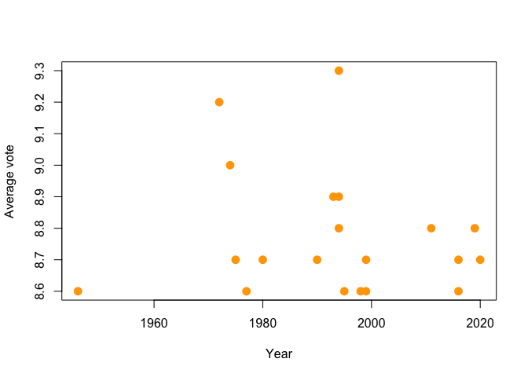

```r
# fun extra, plot the output of your debugging!
plot(top_votes_USA$year, top_votes_USA$avg_vote,
     col = "orange", # point colour
     pch = 16, # point type
     cex = 1.5, # point size
     xlab = "Year",
     ylab = "Average vote")
```

# Final task - Please give us your individual feedback!

This is the first time that we are exploring a remote learning format for our workshops and we would be grateful if you could take 2 mins before the end of the workshop to get your feedback!

The solutions we be available from a link at the end of the survey.

# Individual coding challenge

For this coding challenge we are going to extract all Tolkien (lord of the rings and hobbit) and Harry Potter films from our imdb dataset. We have provided vectors with the titles of these films.

1. Using the Tolkien and Potter vectors, use the `%in%` operator to filter titles in the imdb dataset that match the Tolkien or Potter vectors.
2. Select out the title, year, avg_vote, and duration columns
3. Save your subsetted data to a data frame called Tolkien_Potter
4. What films in the Tolkien_Potter dataset have a higher than average vote?
5. What films in the Tolkien_Potter dataset have a less than average duration in hours?

*hint: for 4 and 5 you can use filter to compare the column to the mean of that column, e.g. filter(data, column > mean(column))*

```r
Tolkien <- c("The Lord of the Rings: The Fellowship of the Ring", "The Lord of the Rings: The Return of the King",
           "The Lord of the Rings: The Two Towers", "The Hobbit: An Unexpected Journey",
           "The Hobbit: The Desolation of Smaug", "The Hobbit: The Battle of the Five Armies")

Potter <- c("Harry Potter and the Sorcerer's Stone", "Harry Potter and the Chamber of Secrets",
            "Harry Potter and the Prisoner of Azkaban", "Harry Potter and the Goblet of Fire",
            "Harry Potter and the Order of the Phoenix", "Harry Potter and the Half-Blood Prince",
            "Harry Potter and the Deathly Hallows: Part 1", "Harry Potter and the Deathly Hallows: Part 2")

# your code here

Tolkien_Potter <- imdb_sub %>%
  filter(title %in% Tolkien | title %in% Potter) %>%
  select(title, year, avg_vote, duration)

filter(Tolkien_Potter, avg_vote > mean(avg_vote))
```

```
## # A tibble: 4 x 4
##   title                                              year avg_vote duration
##   <chr>                                             <dbl>    <dbl>    <dbl>
## 1 The Lord of the Rings: The Fellowship of the Ring  2001      8.8      178
## 2 The Lord of the Rings: The Return of the King      2003      8.9      201
## 3 The Lord of the Rings: The Two Towers              2002      8.7      179
## 4 Harry Potter and the Deathly Hallows: Part 2       2011      8.1      130
```

```r
filter(Tolkien_Potter, duration < mean(duration))
```

```
## # A tibble: 8 x 4
##   title                                         year avg_vote duration
##   <chr>                                        <dbl>    <dbl>    <dbl>
## 1 Harry Potter and the Sorcerer's Stone         2001      7.6      152
## 2 Harry Potter and the Prisoner of Azkaban      2004      7.9      142
## 3 Harry Potter and the Goblet of Fire           2005      7.7      157
## 4 Harry Potter and the Order of the Phoenix     2007      7.5      138
## 5 Harry Potter and the Half-Blood Prince        2009      7.6      153
## 6 Harry Potter and the Deathly Hallows: Part 1  2010      7.7      146
## 7 Harry Potter and the Deathly Hallows: Part 2  2011      8.1      130
## 8 The Hobbit: The Battle of the Five Armies     2014      7.4      144
```